# Red Wine Quality

## Fixed Acidity

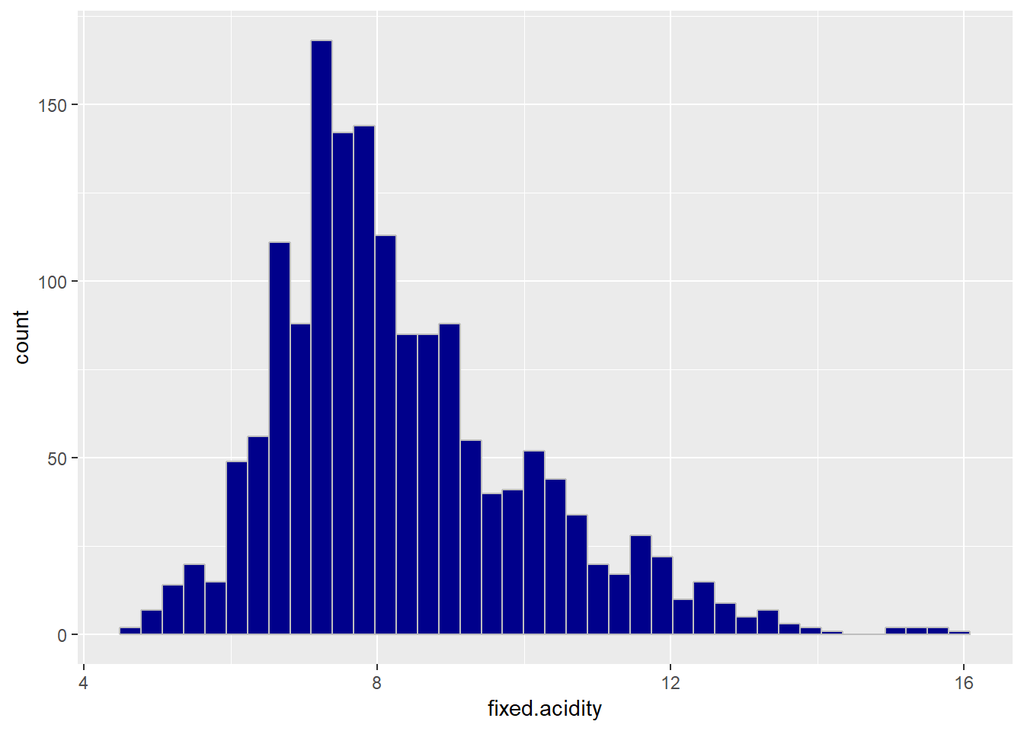

As we can see in the figure the most wine have fixed acidity between 6 and 9 g/dm^3,also the The mean is 8.32 and the max is 15.90.

## Volatile acidity

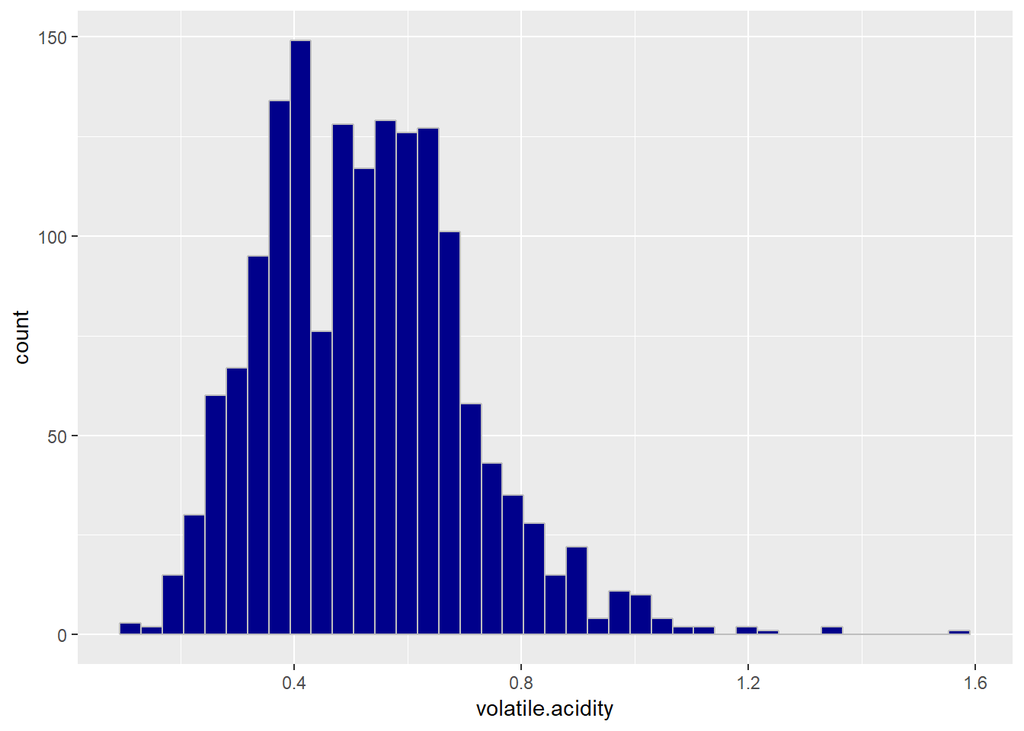

As we can see in the figure the peak at 0.4,the most wine have fixed acidity between 0.3 and 0.7 g/dm^3 and the mean is 0.52 and the max is 1.58.

## Citric acid

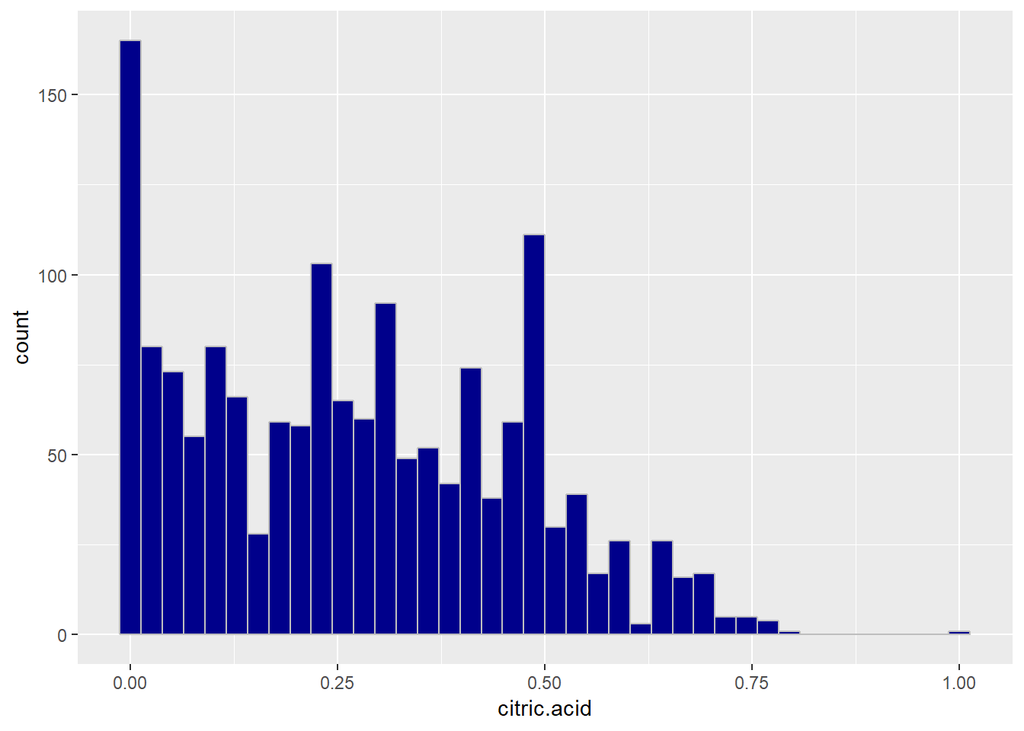

## Residual sugar

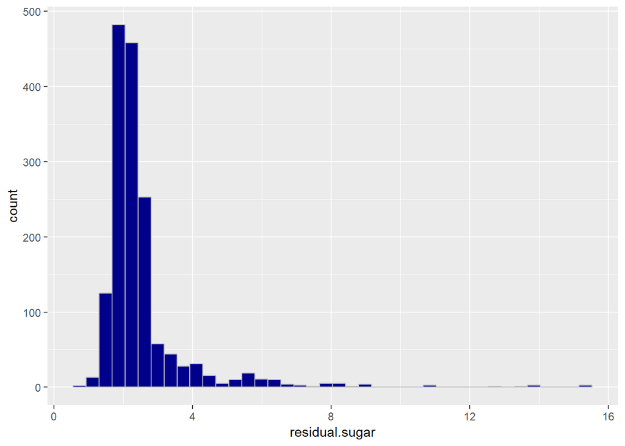

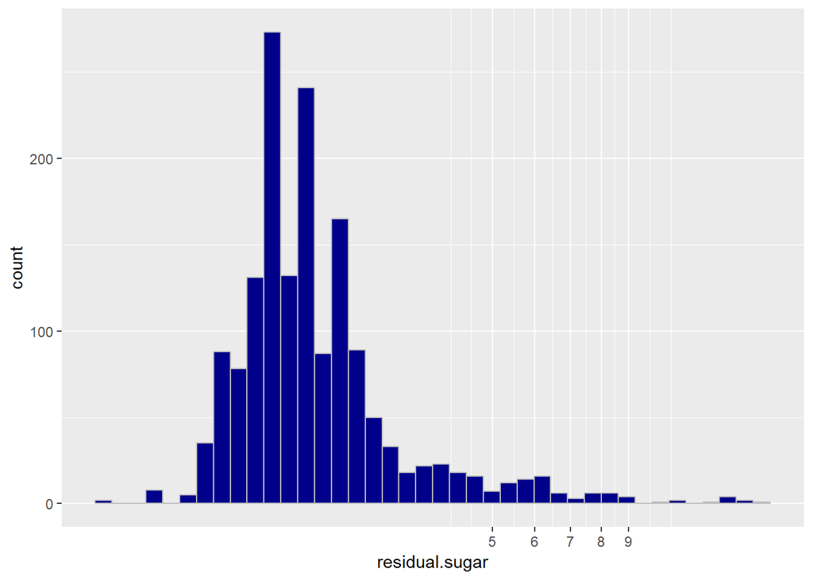

As we can see in the above figure the distribution represent the right skewed. The mean is 2.539 g/dm^3 and the max is 15.500 g/dm^3.

## Chlorides

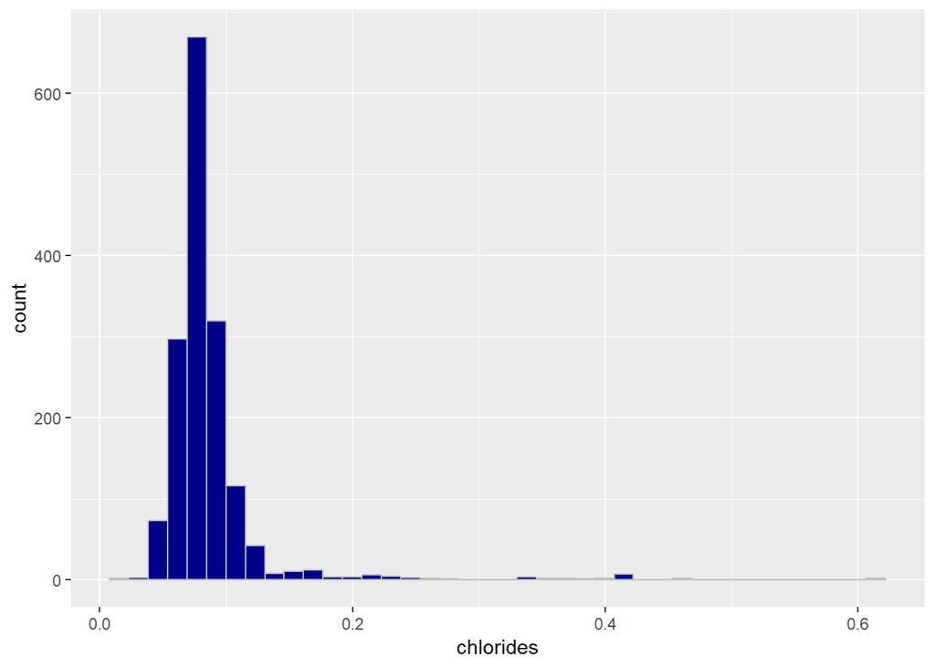

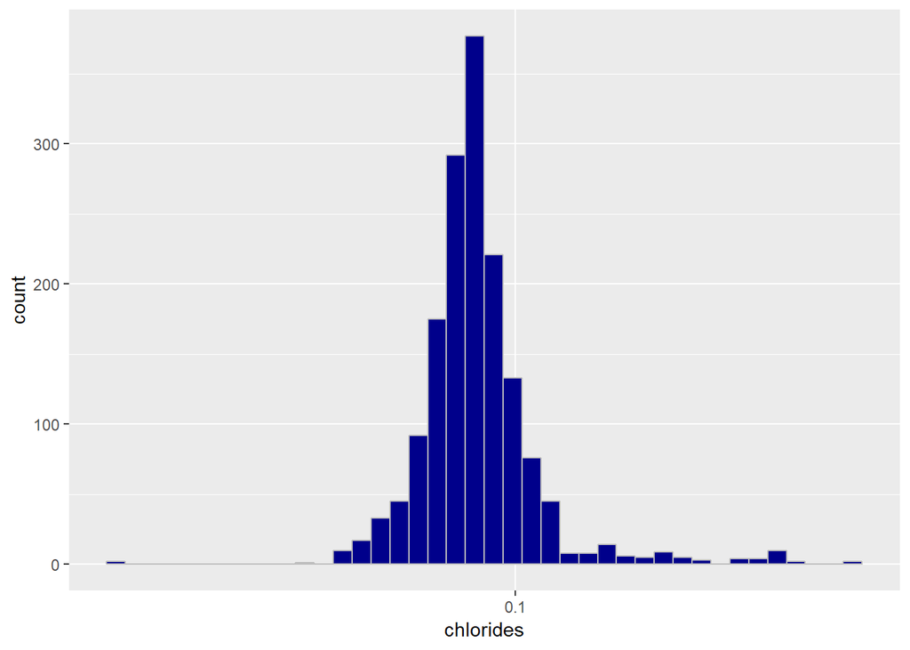

As we can see The distribution in chloride is symmetric and we can see the peak at 0.09 g/dm^3 The mean is 0.08747 g/dm^3.

## Free sulfur dioxide

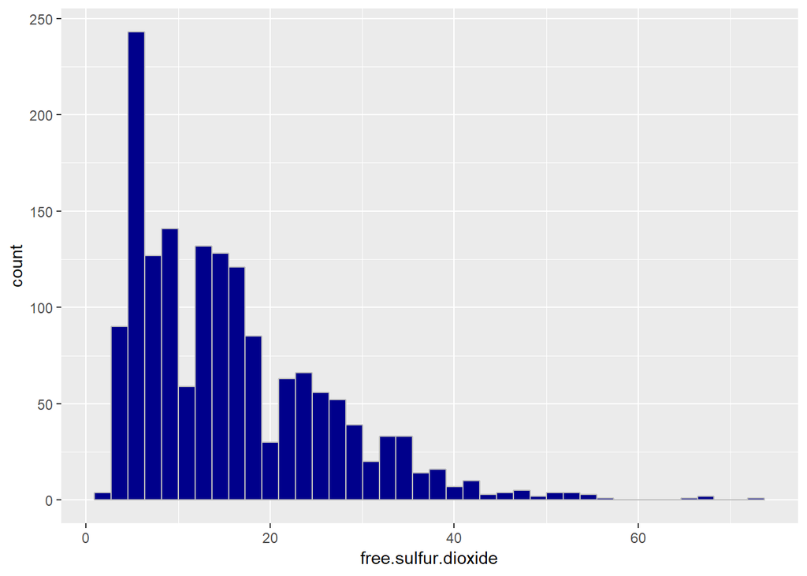

As we can see The distribution in free sulfur dioxide s right skewed and we can see the peak at 5 g/dm^3 The mean is 15.87 g/dm^3.

## Total sulfur dioxide

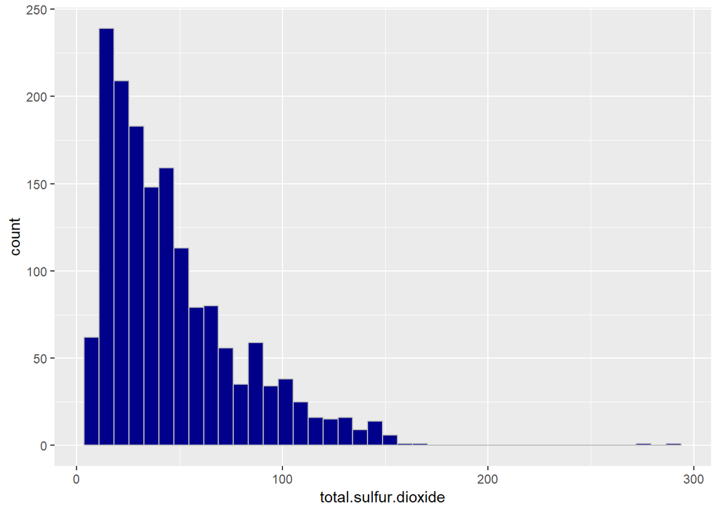

## Density

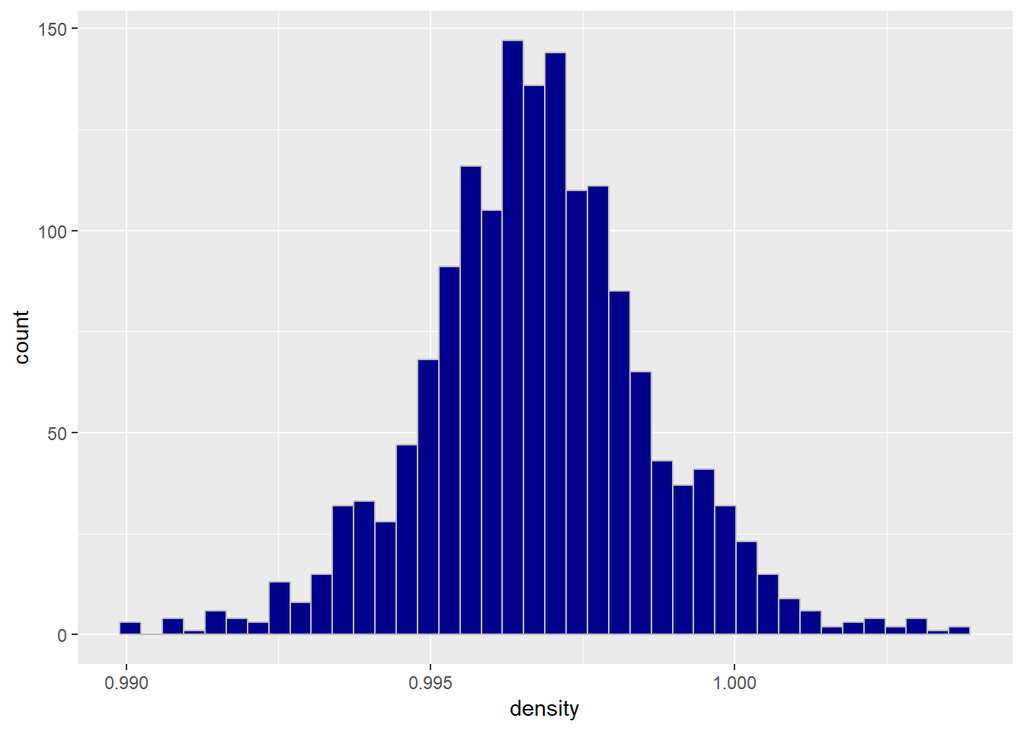

As we can see The distribution in density is symmetric, and we can see the most red wine have density between 0.9950 - 0.9980 The mean is 0.9967 g/cm^3.

## pH

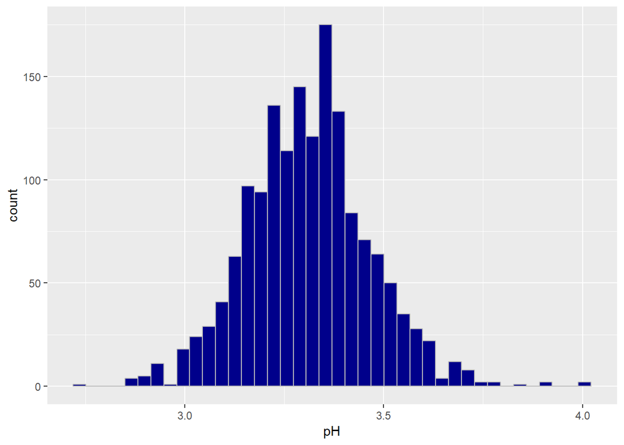

As we can see in the above figure the distribution represent symmetric. The mean is 3.311 and the max is 4.010.

## Sulphates

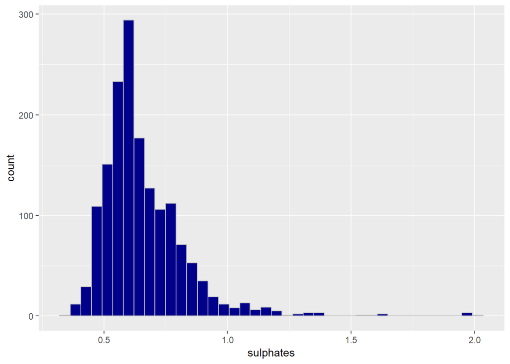

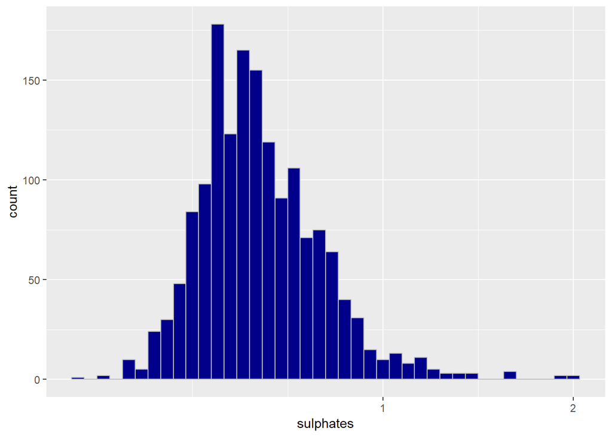

## Alcohol

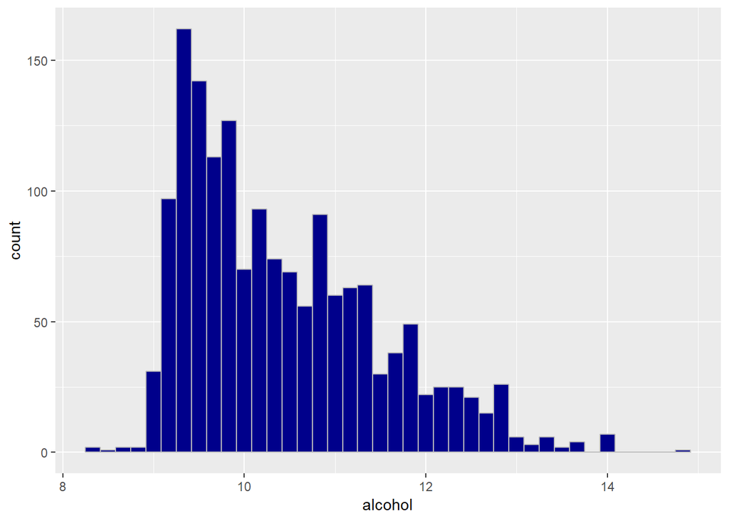

As we can see The distribution in alcohol is right skewed and we can see the peak betwwen 9.1 and 9,5 ,The mean is 10.42 and the max 14.90 .

# Univariate Analysis

### What is the structure of your dataset?

There are 12 colums and 1599 rows

1599:red wines 12: components

### What is/are the main feature(s) of interest in your dataset?

In my opinen the main interest is quality,and I will work on the ingredients that improve the quslity of win.

### What other features in the dataset do you think will help support your investigation into your feature(s) of interest?

I think (alcohol,volatile.acidity,sulphates)

### Did you create any new variables from existing variables in the dataset?

yes,we created variable with name ‘ranking’ for categorie(low,good,very good).

### Of the features you investigated, were there any unusual distributions? Did you perform any operations on the data to tidy, adjust, or change the form of the data? If so, why did you do this?

There is no distributions unusual just we saw right skewed and symmetric, and i thank there is correlation with the quality of red wine. we did not clean or do some change to dataset.

# Bivariate Plots Section

As a starting point let us have a look at a correlation matrix:

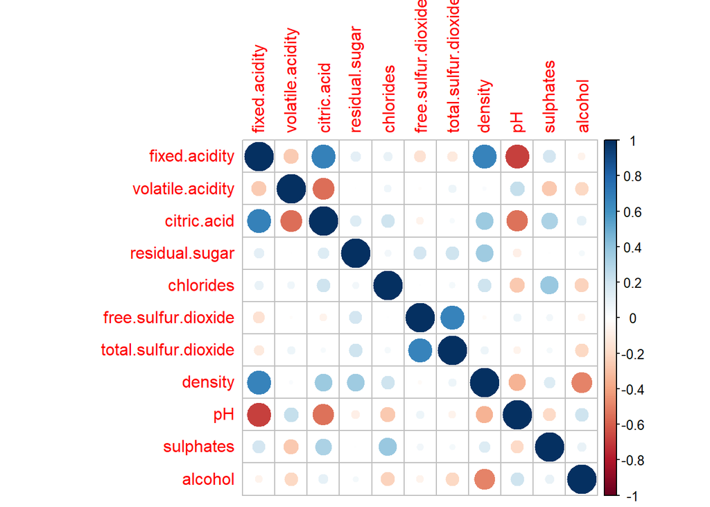

As we can see in the correlation matrix there is positive correlation between density and fixed.acidity , and negative correlation between total.sulfur.dioxide and alcohol ,positive correlation between density and residual.sugar.

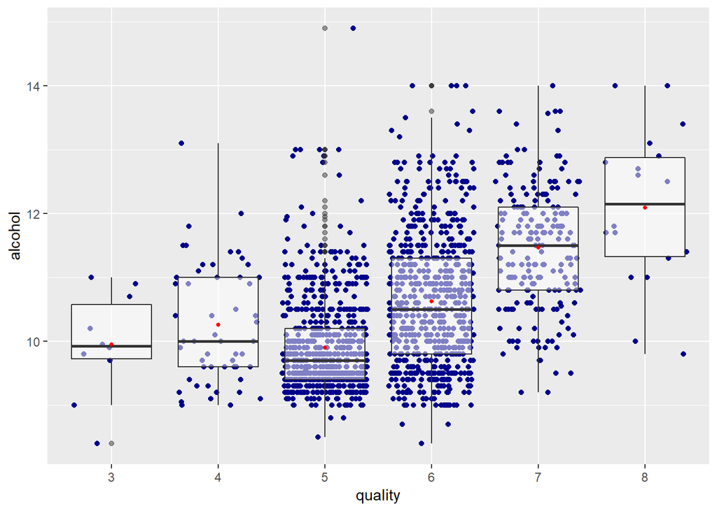

As we can see in the figure above whenever you higher the alcohol is the higher the quality the correlation between alcohol and quality called positive relationship.

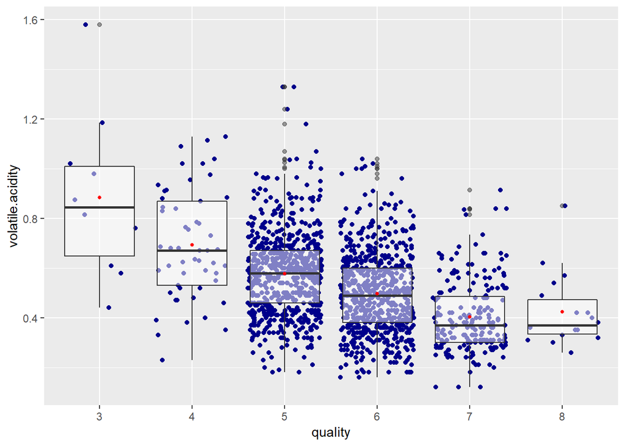

As we can see in the figure above whenever you lower the volatile.acidity is the higher the qualith the correlation between volatile.acidity and qualith called inverse relationship.

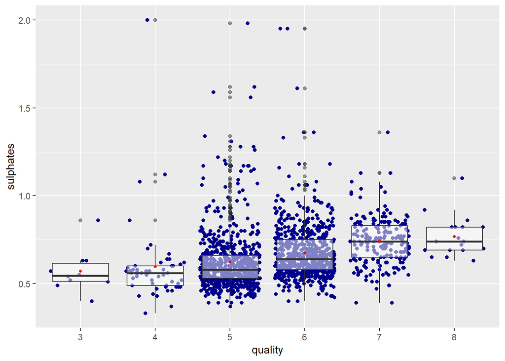

As we can see in the figure above whenever you higher the sulphates is the higher the quality the correlation coefficient between sulphates and quality called positive relationship.

# Bivariate Analysis

### How did the feature(s) of interest vary with other features in dataset?

After did some analysis we noticed that there is a negative relationship between the quality and volatile.acidity on the other hand we found that there is a positive relationship between quality and sulphates.

### Did you observe any interesting relationships between the other features (not the main feature(s) of interest)?

Yes, we noticed there is a positive relationship between density and residual.sugar,also between chlorides and density

### What was the strongest relationship you found?

The quality has the strongest relationship with alcohol.

# Multivariate Plots Section

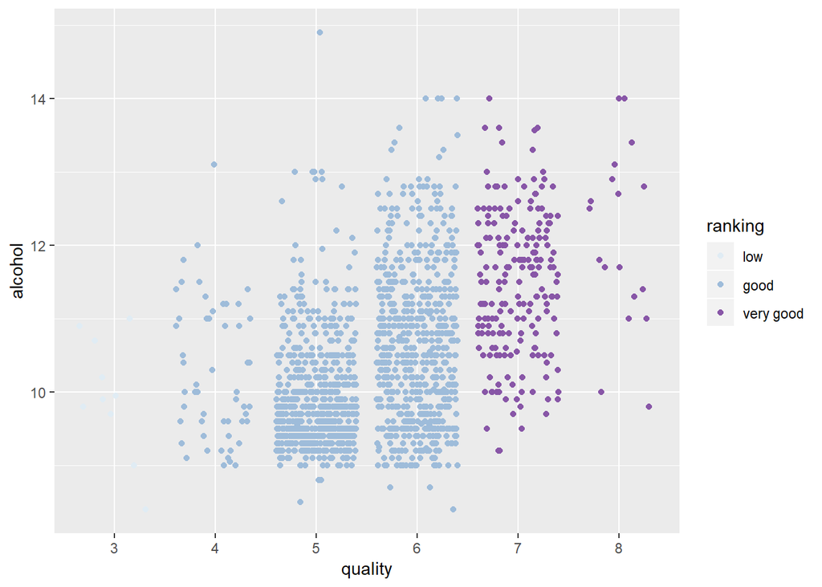

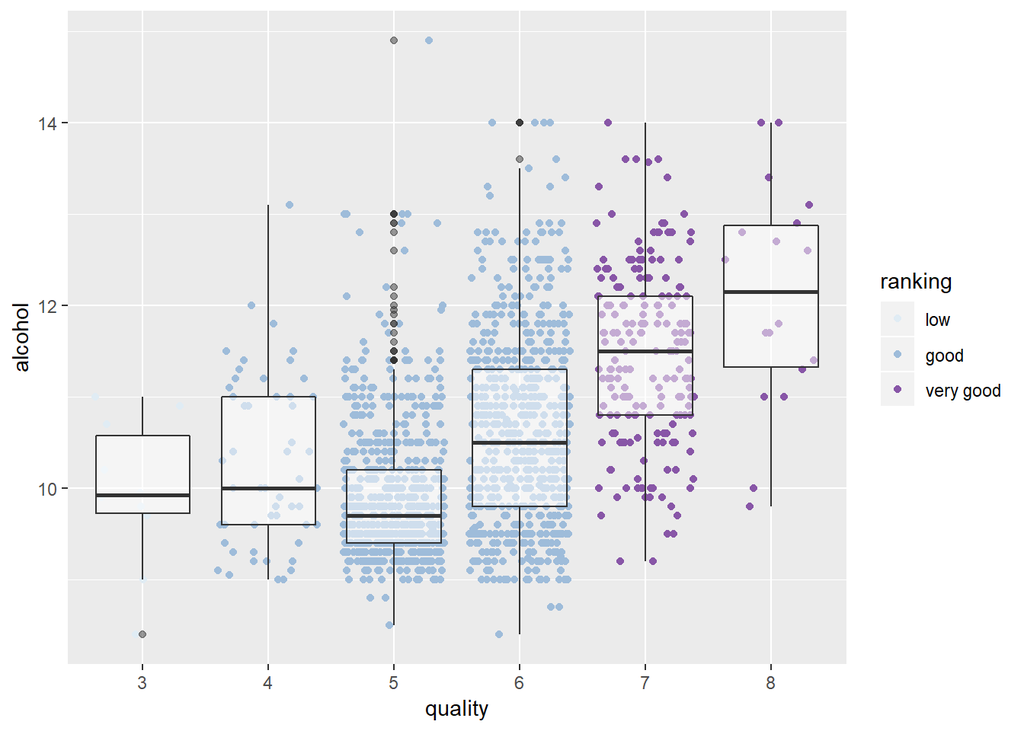

As we can see in the figure above the most distribution was in good and very good ranking between 4.5 and 7.

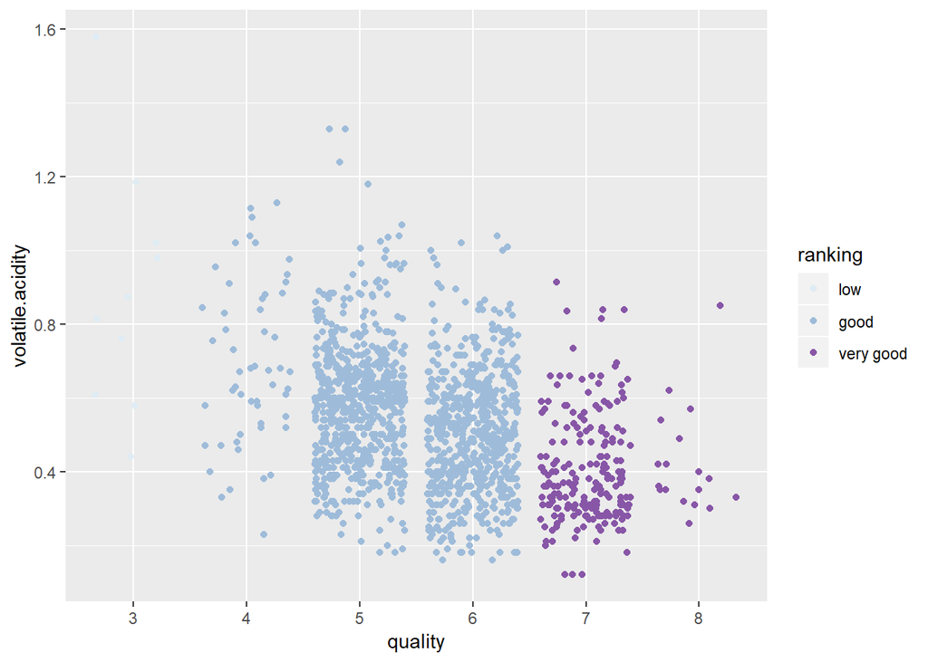

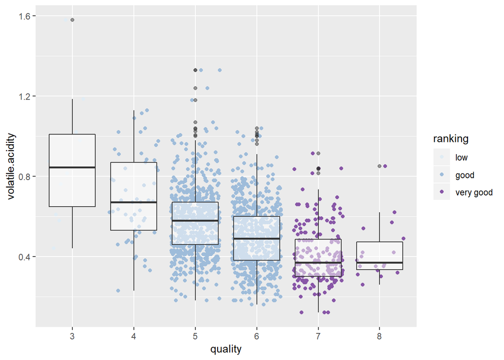

As we can see in the figure above the most distribution was in good ranking between 4.5 and 6.2.

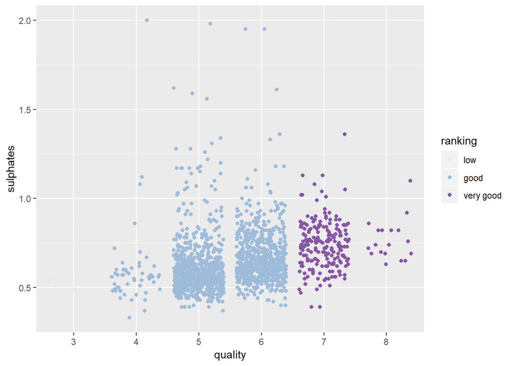

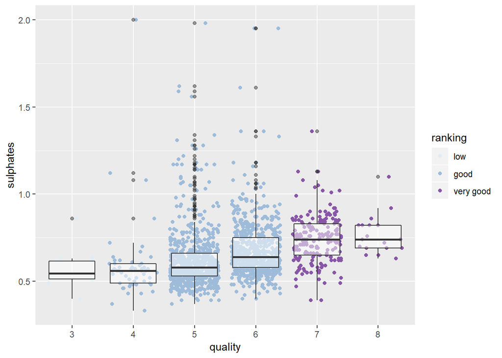

As we can see in the figure above the most distribution was in good and very good ranking between 4.5 and 7.

### Were there features that strengthened each other in terms of at your feature(s) of interest?

we found that there are a positive relationship and strong between alcohol and quality and whenever you higher the alcohol is the higher the quality red wine

### Were there any interesting or surprising interactions between features?

# Final Plots and Summary

### Plot One

```
##   3   4   5   6   7   8
##  10  53 681 638 199  18
```

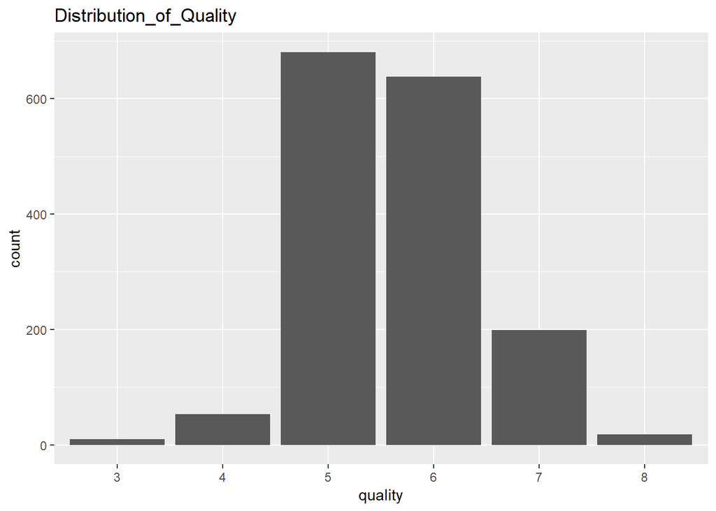

### Description One

As we can see the most distribution of red wine quality is normal between 5 and 6 .

### Plot Two

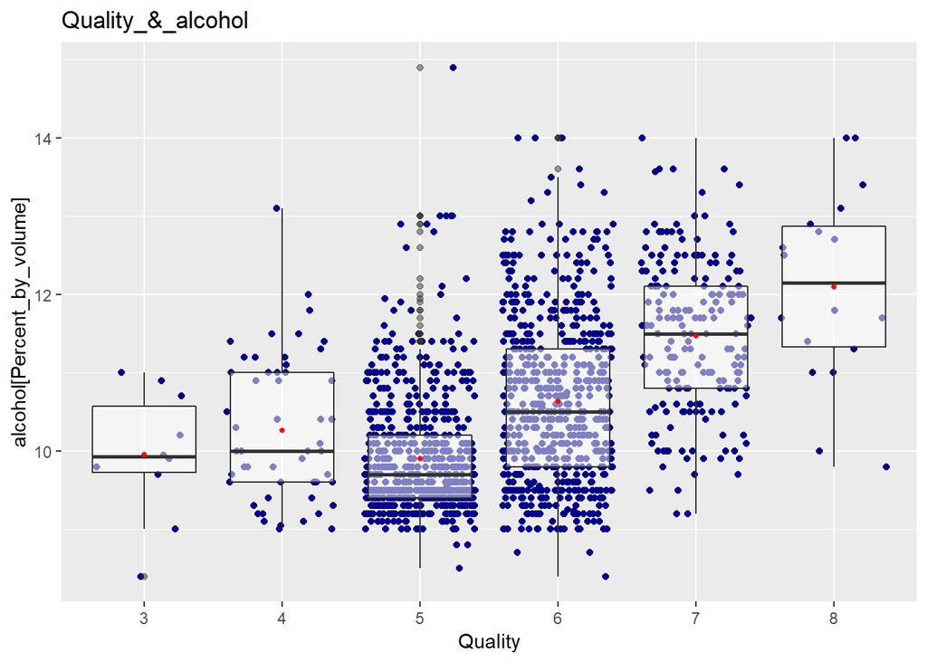

### Description Two

The correlation coefficient between alcohol and quality is 0.47 and that Indicates there a positive relationship.

### Plot Three

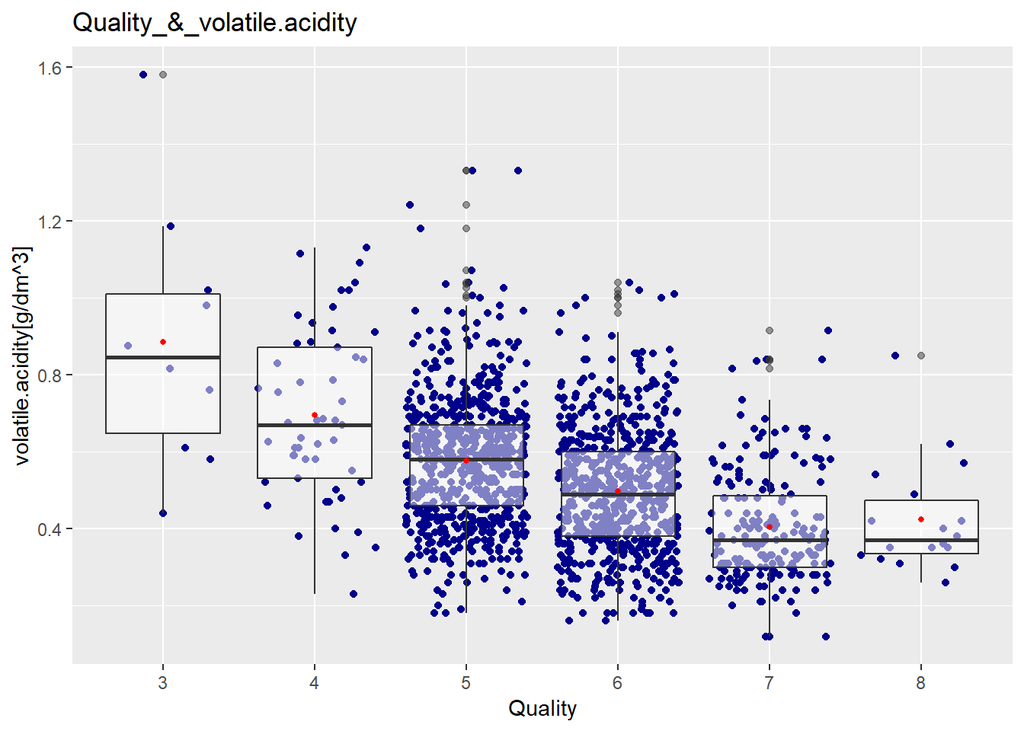

### Description Three

The correlation coefficient between volatile.acidity and quality is negitive and that Indicates there a reverse relationship.

# Reflection

In the beginng we chose the Red Wine Quality dataset it’s has 1599 kind of wines and 12 variants,then we started understand the variables by do explored every variable.

After that we have some question and tryied to solved by do correlation matricx and did visualize the relationships between the variables and see if there any relationship.

We noticed that there is strong positive relastionship between alcohol and quality so, we can say to get red Wine with high Quality you suppposed we have high alcohol . and there some varibles as voilatile.acidity has reverse relationship.

As we can predict the quality of wine by using alcohol and voilatile.acidity in case we look for high quality we will see alcohol and in case we look for low quality we will see voilatile.acidity

It is also possible that if we had a dataset and variables bigger then our dataset on red wine, the analysis would be more accurate to confirm that alcohol increases the quality of red wine.

### References

https://www.youtube.com/watch?v=1e3PhugevPM

https://www.statmethods.net/graphs/bar.html

http://www.r-graph-gallery.com/41-value-of-the-col-function/ https://www.youtube.com/watch?v=1e3PhugevPM

https://en.wikipedia.org/wiki/Citric_acid

https://raw.githubusercontent.com/jasminej90/dandp4-explore-and-summarize-data/master/project.html

https://www.datamentor.io/r-programming/histogram/

http://dataaspirant.com/2017/10/05/create-histograms-r/

http://www.sthda.com/english/wiki/visualize-correlation-matrix-using-correlogram

https://ggplot2.tidyverse.org/reference/annotation_logticks.html

http://ggplot.yhathq.com/docs/scale_x_log10.html